# CodingProject3

```python
# name: Hsin Yu Chen
# date: 3/12/2024
# course number: CSC647-01
# CP #3 This coding project implements Grover’s Search, and analyzes probabilities and gate counts.
```

### Coding Project #3 – Grover’s Search

#### Part 1: 2-qubit configuration

```
Oracle Unitary Matrix:
```

$$ \begin{bmatrix} 1 & 0 & 0 & 0 \\ 0 & 1 & 0 & 0 \\ 0 & 0 & -1 & 0 \\ 0 & 0 & 0 & 1 \\ \end{bmatrix} $$

```
Oracle Circuit:
```

```
     ┌───┐   ┌───┐
q_0: ┤ X ├─■─┤ X ├
     └───┘ │ └───┘
q_1: ──────■──────
```

```
Iteration 1
```

```
     ┌───┐┌───┐   ┌───┐┌───┐┌───┐   ┌───┐
q_0: ┤ H ├┤ X ├─■─┤ X ├┤ H ├┤ Z ├─■─┤ H ├
     ├───┤└───┘ │ ├───┤├───┤└───┘ │ ├───┤
q_1: ┤ H ├──────■─┤ H ├┤ Z ├──────■─┤ H ├
     └───┘        └───┘└───┘        └───┘
```

```
State vector after iteration 1 : Statevector([2.36158002e-17+0.j, 1.26316153e-34+0.j, 1.00000000e+00+0.j,
             9.52420783e-18+0.j],
            dims=(2, 2))
```

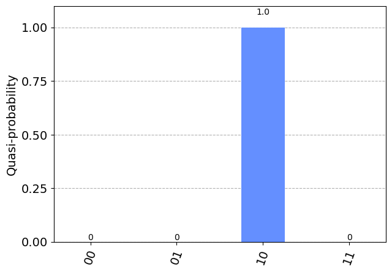

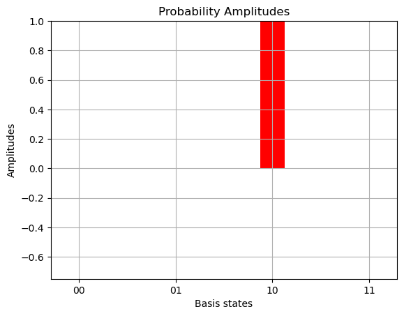

```
Iteration 2
```

```
     ┌───┐┌───┐   ┌───┐┌───┐┌───┐   ┌───┐┌───┐   ┌───┐┌───┐┌───┐   ┌───┐
q_0: ┤ H ├┤ X ├─■─┤ X ├┤ H ├┤ Z ├─■─┤ H ├┤ X ├─■─┤ X ├┤ H ├┤ Z ├─■─┤ H ├
     ├───┤└───┘ │ ├───┤├───┤└───┘ │ ├───┤└───┘ │ ├───┤├───┤└───┘ │ ├───┤
q_1: ┤ H ├──────■─┤ H ├┤ Z ├──────■─┤ H ├──────■─┤ H ├┤ Z ├──────■─┤ H ├
     └───┘        └───┘└───┘        └───┘        └───┘└───┘        └───┘
```

```
State vector after iteration 2 : Statevector([-0.5+0.j, -0.5+0.j,  0.5+0.j, -0.5+0.j],
            dims=(2, 2))
```

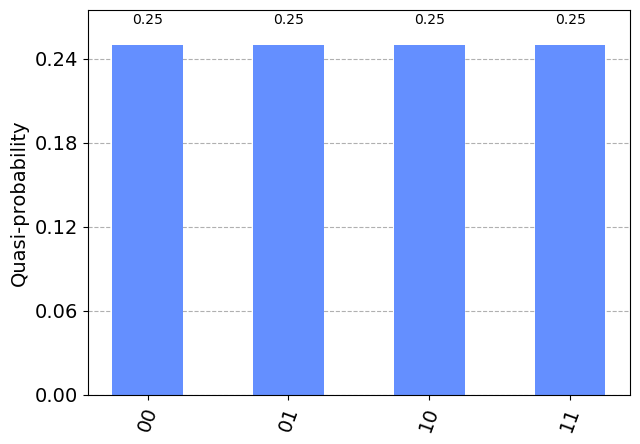

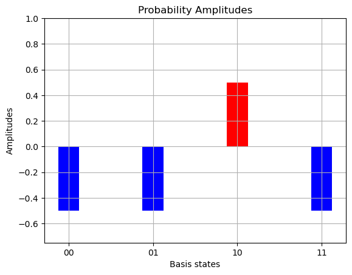

```
Iteration 3
```

```
     ┌───┐┌───┐   ┌───┐┌───┐┌───┐   ┌───┐┌───┐   ┌───┐┌───┐┌───┐   ┌───┐┌───┐»
q_0: ┤ H ├┤ X ├─■─┤ X ├┤ H ├┤ Z ├─■─┤ H ├┤ X ├─■─┤ X ├┤ H ├┤ Z ├─■─┤ H ├┤ X ├»
     ├───┤└───┘ │ ├───┤├───┤└───┘ │ ├───┤└───┘ │ ├───┤├───┤└───┘ │ ├───┤└───┘»
q_1: ┤ H ├──────■─┤ H ├┤ Z ├──────■─┤ H ├──────■─┤ H ├┤ Z ├──────■─┤ H ├─────»
     └───┘        └───┘└───┘        └───┘        └───┘└───┘        └───┘     »
«        ┌───┐┌───┐┌───┐   ┌───┐
«q_0: ─■─┤ X ├┤ H ├┤ Z ├─■─┤ H ├
«      │ ├───┤├───┤└───┘ │ ├───┤
«q_1: ─■─┤ H ├┤ Z ├──────■─┤ H ├
«        └───┘└───┘        └───┘
```

```
State vector after iteration 3 : Statevector([-0.5+0.j, -0.5+0.j, -0.5+0.j, -0.5+0.j],
            dims=(2, 2))
```

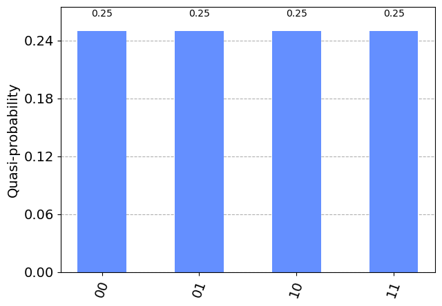

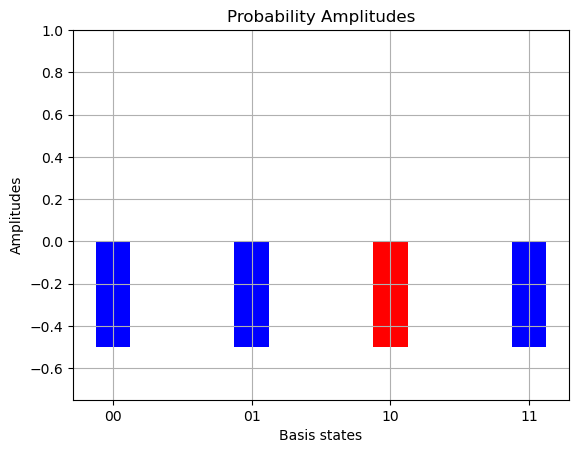

```python
from qiskit import QuantumCircuit
from qiskit.visualization import plot_distribution, plot_state_qsphere
from qiskit.quantum_info import Statevector, Operator
import numpy as np
import matplotlib.pyplot as plt
from IPython.display import display

# Initialize the quantum circuit
def init_n_qubit_circuit(n):
    qc = QuantumCircuit(n)
    return qc

def apply_n_hgates(qc, n):
    for i in range(n):
        qc.h(i)
    return qc

# Define the Oracle circuit for the target state |10>
def grover_oracle_2qb(qc):
    qc.x(0)
    qc.cz(0, 1)
    qc.x(0)
    return qc

# Define the Diffuser circuit
def grover_diffuser_2qb(qc):
    qc.h([0, 1])
    qc.z([0, 1])
    qc.cz(0, 1)
    qc.h([0, 1])
    return qc

def plot_amplitudes_2qb(r, string):
    x_axis = np.arange(0, 4, 1)
    colors = ['blue', 'blue', 'red', 'blue']
    axis_labels = ['00', '01', '10', '11']

    plt.grid()
    plt.bar(x_axis, r, width=0.25, tick_label=axis_labels, color=colors)
    plt.ylim(-0.75, 1)

    plt.title(string)
    plt.xlabel('Basis states')
    plt.ylabel('Amplitudes')
    plt.show()

# Initialize the quantum circuit
t = init_n_qubit_circuit(2)
t = apply_n_hgates(t, 2)

# display the unitary matrix
oracle_circuit = QuantumCircuit(2)
grover_oracle_2qb(oracle_circuit)
oracle_operator = Operator(oracle_circuit)
latex_representation = oracle_operator.draw("latex")

print("Oracle Unitary Matrix:")
display(latex_representation)
print("Oracle Circuit:")
display(oracle_circuit.draw())

for i in range(3):
    # Apply Oracle
    grover_oracle_2qb(t)

    # Apply Diffuser
    grover_diffuser_2qb(t)

    print("Iteration", i+1)
    display(t.draw())

    # Obtain and print the state vector
    sv = Statevector(t)
    print("State vector after iteration", i+1, ":", sv)

    # Plot the probability distribution
    display(plot_distribution(sv.probabilities_dict()))

    # Plot the probability amplitudes
    plot_amplitudes_2qb(sv.data.real, "Probability Amplitudes")
```

Iteration 1: After the first iteration, the probability amplitude for the state |10⟩ is maximized to 1, while the probabilities for other states are zero. This aligns with the desired outcome of finding the target state.

Iteration 3: Similarly to the second iteration, the probability amplitudes remain evenly distributed among all basis states, each with a probability of 0.25. This distribution persists as the algorithm continues to iterate.

For one iteration:

[output not shown]

For three iterations:

[output not shown]

#### Part 2: 3-qubit configuration

```
Oracle Unitary Matrix:
```

$$ \begin{bmatrix} 1 & 0 & 0 & 0 & 0 & 0 & 0 & 0 \\ 0 & 1 & 0 & 0 & 0 & 0 & 0 & 0 \\ 0 & 0 & 1 & 0 & 0 & 0 & 0 & 0 \\ 0 & 0 & 0 & 1 & 0 & 0 & 0 & 0 \\ 0 & 0 & 0 & 0 & 1 & 0 & 0 & 0 \\ 0 & 0 & 0 & 0 & 0 & 1 & 0 & 0 \\ 0 & 0 & 0 & 0 & 0 & 0 & -1 & 0 \\ 0 & 0 & 0 & 0 & 0 & 0 & 0 & 1 \\ \end{bmatrix} $$

```
Oracle Circuit:
     ┌───┐     ┌───┐
q_0: ┤ X ├──■──┤ X ├
     └───┘  │  └───┘
q_1: ───────■───────
     ┌───┐┌─┴─┐┌───┐
q_2: ┤ H ├┤ X ├┤ H ├
     └───┘└───┘└───┘
Iteration 1
```

```
     ┌───┐┌───┐     ┌───┐┌───┐┌───┐          ┌───┐┌───┐
q_0: ┤ H ├┤ X ├──■──┤ X ├┤ H ├┤ X ├───────■──┤ X ├┤ H ├─────
     ├───┤└───┘  │  ├───┤├───┤└───┘       │  ├───┤├───┤
q_1: ┤ H ├───────■──┤ H ├┤ X ├────────────■──┤ X ├┤ H ├─────
     ├───┤┌───┐┌─┴─┐├───┤├───┤┌───┐┌───┐┌─┴─┐├───┤├───┤┌───┐
q_2: ┤ H ├┤ H ├┤ X ├┤ H ├┤ H ├┤ X ├┤ H ├┤ X ├┤ H ├┤ X ├┤ H ├
     └───┘└───┘└───┘└───┘└───┘└───┘└───┘└───┘└───┘└───┘└───┘
```

```
State vector after iteration 1 : Statevector([-0.1767767 +0.j, -0.1767767 +0.j, -0.1767767 +0.j,
             -0.1767767 +0.j, -0.1767767 +0.j, -0.1767767 +0.j,
             -0.88388348+0.j, -0.1767767 +0.j],
            dims=(2, 2, 2))
```

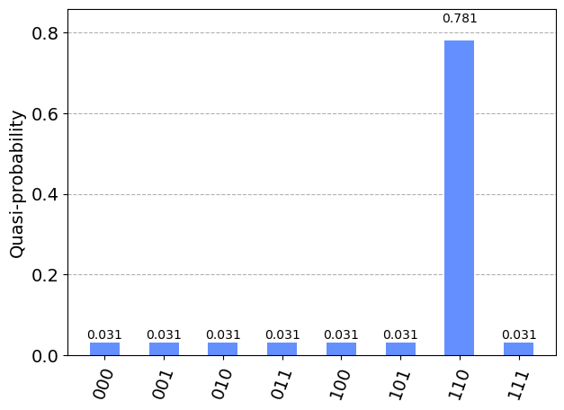

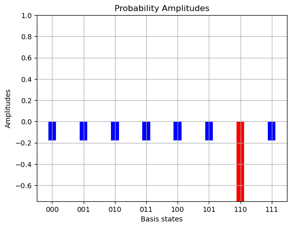

```
Iteration 2
```

```
     ┌───┐┌───┐     ┌───┐┌───┐┌───┐          ┌───┐┌───┐┌───┐          ┌───┐»
q_0: ┤ H ├┤ X ├──■──┤ X ├┤ H ├┤ X ├───────■──┤ X ├┤ H ├┤ X ├───────■──┤ X ├»
     ├───┤└───┘  │  ├───┤├───┤└───┘       │  ├───┤├───┤└───┘       │  ├───┤»
q_1: ┤ H ├───────■──┤ H ├┤ X ├────────────■──┤ X ├┤ H ├────────────■──┤ H ├»
     ├───┤┌───┐┌─┴─┐├───┤├───┤┌───┐┌───┐┌─┴─┐├───┤├───┤┌───┐┌───┐┌─┴─┐├───┤»
q_2: ┤ H ├┤ H ├┤ X ├┤ H ├┤ H ├┤ X ├┤ H ├┤ X ├┤ H ├┤ X ├┤ H ├┤ H ├┤ X ├┤ H ├»
     └───┘└───┘└───┘└───┘└───┘└───┘└───┘└───┘└───┘└───┘└───┘└───┘└───┘└───┘»
«     ┌───┐┌───┐          ┌───┐┌───┐
«q_0: ┤ H ├┤ X ├───────■──┤ X ├┤ H ├─────
«     ├───┤└───┘       │  ├───┤├───┤
«q_1: ┤ X ├────────────■──┤ X ├┤ H ├─────
«     ├───┤┌───┐┌───┐┌─┴─┐├───┤├───┤┌───┐
«q_2: ┤ H ├┤ X ├┤ H ├┤ X ├┤ H ├┤ X ├┤ H ├
«     └───┘└───┘└───┘└───┘└───┘└───┘└───┘
```

```
State vector after iteration 2 : Statevector([-0.08838835+0.j, -0.08838835+0.j, -0.08838835+0.j,
             -0.08838835+0.j, -0.08838835+0.j, -0.08838835+0.j,
              0.97227182+0.j, -0.08838835+0.j],
            dims=(2, 2, 2))
```

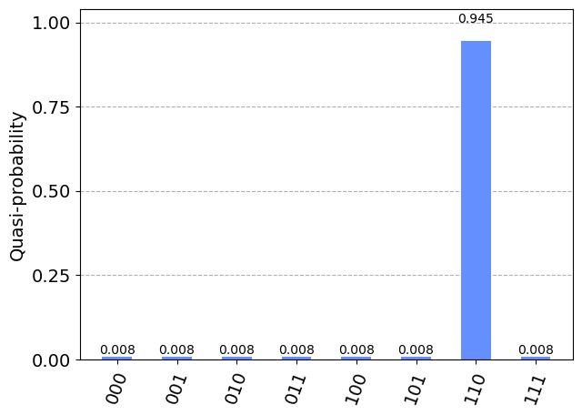

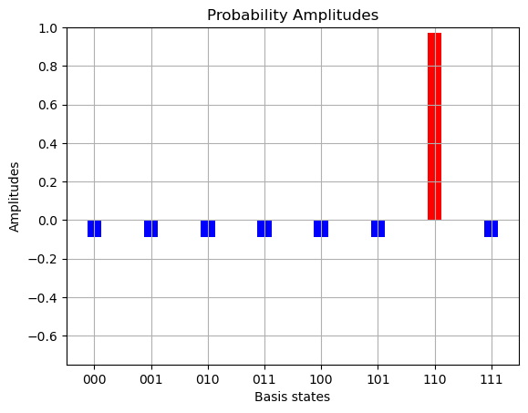

```
Iteration 3
```

```
     ┌───┐┌───┐     ┌───┐┌───┐┌───┐          ┌───┐┌───┐┌───┐          ┌───┐»
q_0: ┤ H ├┤ X ├──■──┤ X ├┤ H ├┤ X ├───────■──┤ X ├┤ H ├┤ X ├───────■──┤ X ├»
     ├───┤└───┘  │  ├───┤├───┤└───┘       │  ├───┤├───┤└───┘       │  ├───┤»
q_1: ┤ H ├───────■──┤ H ├┤ X ├────────────■──┤ X ├┤ H ├────────────■──┤ H ├»
     ├───┤┌───┐┌─┴─┐├───┤├───┤┌───┐┌───┐┌─┴─┐├───┤├───┤┌───┐┌───┐┌─┴─┐├───┤»
q_2: ┤ H ├┤ H ├┤ X ├┤ H ├┤ H ├┤ X ├┤ H ├┤ X ├┤ H ├┤ X ├┤ H ├┤ H ├┤ X ├┤ H ├»
     └───┘└───┘└───┘└───┘└───┘└───┘└───┘└───┘└───┘└───┘└───┘└───┘└───┘└───┘»
«     ┌───┐┌───┐          ┌───┐┌───┐┌───┐          ┌───┐┌───┐┌───┐          »
«q_0: ┤ H ├┤ X ├───────■──┤ X ├┤ H ├┤ X ├───────■──┤ X ├┤ H ├┤ X ├───────■──»
«     ├───┤└───┘       │  ├───┤├───┤└───┘       │  ├───┤├───┤└───┘       │  »
«q_1: ┤ X ├────────────■──┤ X ├┤ H ├────────────■──┤ H ├┤ X ├────────────■──»
«     ├───┤┌───┐┌───┐┌─┴─┐├───┤├───┤┌───┐┌───┐┌─┴─┐├───┤├───┤┌───┐┌───┐┌─┴─┐»
«q_2: ┤ H ├┤ X ├┤ H ├┤ X ├┤ H ├┤ X ├┤ H ├┤ H ├┤ X ├┤ H ├┤ H ├┤ X ├┤ H ├┤ X ├»
«     └───┘└───┘└───┘└───┘└───┘└───┘└───┘└───┘└───┘└───┘└───┘└───┘└───┘└───┘»
«     ┌───┐┌───┐
«q_0: ┤ X ├┤ H ├─────
«     ├───┤├───┤
«q_1: ┤ X ├┤ H ├─────
«     ├───┤├───┤┌───┐
«q_2: ┤ H ├┤ X ├┤ H ├
«     └───┘└───┘└───┘
```

```
State vector after iteration 3 : Statevector([ 0.30935922+0.j,  0.30935922+0.j,  0.30935922+0.j,
              0.30935922+0.j,  0.30935922+0.j,  0.30935922+0.j,
             -0.57452426+0.j,  0.30935922+0.j],
            dims=(2, 2, 2))
```

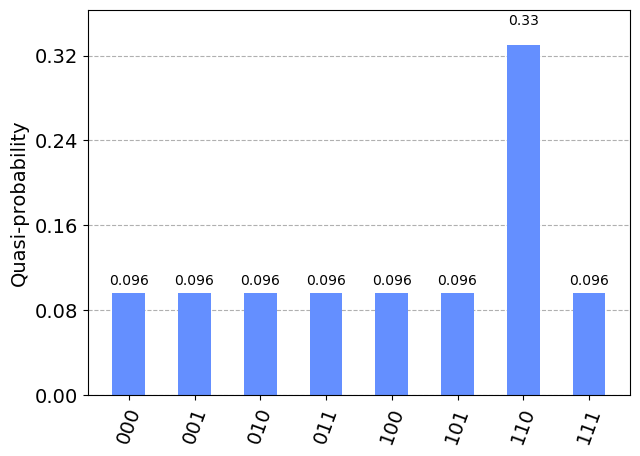

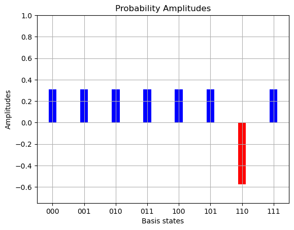

```
Iteration 4
```

```
     ┌───┐┌───┐     ┌───┐┌───┐┌───┐          ┌───┐┌───┐┌───┐          ┌───┐»
q_0: ┤ H ├┤ X ├──■──┤ X ├┤ H ├┤ X ├───────■──┤ X ├┤ H ├┤ X ├───────■──┤ X ├»
     ├───┤└───┘  │  ├───┤├───┤└───┘       │  ├───┤├───┤└───┘       │  ├───┤»
q_1: ┤ H ├───────■──┤ H ├┤ X ├────────────■──┤ X ├┤ H ├────────────■──┤ H ├»
     ├───┤┌───┐┌─┴─┐├───┤├───┤┌───┐┌───┐┌─┴─┐├───┤├───┤┌───┐┌───┐┌─┴─┐├───┤»
q_2: ┤ H ├┤ H ├┤ X ├┤ H ├┤ H ├┤ X ├┤ H ├┤ X ├┤ H ├┤ X ├┤ H ├┤ H ├┤ X ├┤ H ├»
     └───┘└───┘└───┘└───┘└───┘└───┘└───┘└───┘└───┘└───┘└───┘└───┘└───┘└───┘»
«     ┌───┐┌───┐          ┌───┐┌───┐┌───┐          ┌───┐┌───┐┌───┐          »
«q_0: ┤ H ├┤ X ├───────■──┤ X ├┤ H ├┤ X ├───────■──┤ X ├┤ H ├┤ X ├───────■──»
«     ├───┤└───┘       │  ├───┤├───┤└───┘       │  ├───┤├───┤└───┘       │  »
«q_1: ┤ X ├────────────■──┤ X ├┤ H ├────────────■──┤ H ├┤ X ├────────────■──»
«     ├───┤┌───┐┌───┐┌─┴─┐├───┤├───┤┌───┐┌───┐┌─┴─┐├───┤├───┤┌───┐┌───┐┌─┴─┐»
«q_2: ┤ H ├┤ X ├┤ H ├┤ X ├┤ H ├┤ X ├┤ H ├┤ H ├┤ X ├┤ H ├┤ H ├┤ X ├┤ H ├┤ X ├»
«     └───┘└───┘└───┘└───┘└───┘└───┘└───┘└───┘└───┘└───┘└───┘└───┘└───┘└───┘»
«     ┌───┐┌───┐┌───┐          ┌───┐┌───┐┌───┐          ┌───┐┌───┐
«q_0: ┤ X ├┤ H ├┤ X ├───────■──┤ X ├┤ H ├┤ X ├───────■──┤ X ├┤ H ├─────
«     ├───┤├───┤└───┘       │  ├───┤├───┤└───┘       │  ├───┤├───┤
«q_1: ┤ X ├┤ H ├────────────■──┤ H ├┤ X ├────────────■──┤ X ├┤ H ├─────
«     ├───┤├───┤┌───┐┌───┐┌─┴─┐├───┤├───┤┌───┐┌───┐┌─┴─┐├───┤├───┤┌───┐
«q_2: ┤ H ├┤ X ├┤ H ├┤ H ├┤ X ├┤ H ├┤ H ├┤ X ├┤ H ├┤ X ├┤ H ├┤ X ├┤ H ├
«     └───┘└───┘└───┘└───┘└───┘└───┘└───┘└───┘└───┘└───┘└───┘└───┘└───┘
```

```
State vector after iteration 4 : Statevector([-0.37565048+0.j, -0.37565048+0.j, -0.37565048+0.j,
             -0.37565048+0.j, -0.37565048+0.j, -0.37565048+0.j,
             -0.11048543+0.j, -0.37565048+0.j],
            dims=(2, 2, 2))
```

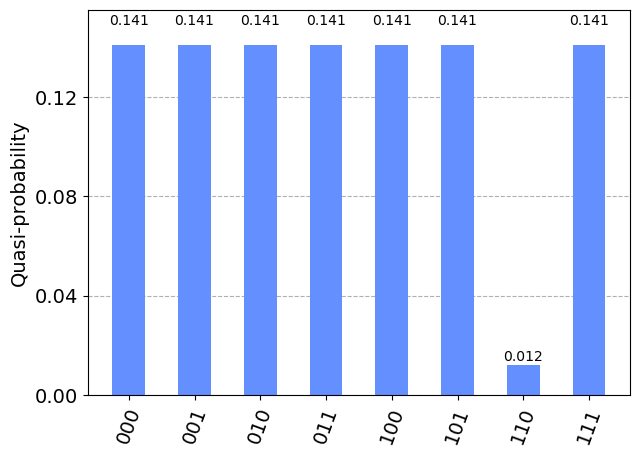

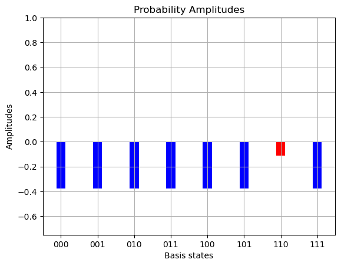

```
Iteration 5
```

```
     ┌───┐┌───┐     ┌───┐┌───┐┌───┐          ┌───┐┌───┐┌───┐          ┌───┐»
q_0: ┤ H ├┤ X ├──■──┤ X ├┤ H ├┤ X ├───────■──┤ X ├┤ H ├┤ X ├───────■──┤ X ├»
     ├───┤└───┘  │  ├───┤├───┤└───┘       │  ├───┤├───┤└───┘       │  ├───┤»
q_1: ┤ H ├───────■──┤ H ├┤ X ├────────────■──┤ X ├┤ H ├────────────■──┤ H ├»
     ├───┤┌───┐┌─┴─┐├───┤├───┤┌───┐┌───┐┌─┴─┐├───┤├───┤┌───┐┌───┐┌─┴─┐├───┤»
q_2: ┤ H ├┤ H ├┤ X ├┤ H ├┤ H ├┤ X ├┤ H ├┤ X ├┤ H ├┤ X ├┤ H ├┤ H ├┤ X ├┤ H ├»
     └───┘└───┘└───┘└───┘└───┘└───┘└───┘└───┘└───┘└───┘└───┘└───┘└───┘└───┘»
«     ┌───┐┌───┐          ┌───┐┌───┐┌───┐          ┌───┐┌───┐┌───┐          »
«q_0: ┤ H ├┤ X ├───────■──┤ X ├┤ H ├┤ X ├───────■──┤ X ├┤ H ├┤ X ├───────■──»
«     ├───┤└───┘       │  ├───┤├───┤└───┘       │  ├───┤├───┤└───┘       │  »
«q_1: ┤ X ├────────────■──┤ X ├┤ H ├────────────■──┤ H ├┤ X ├────────────■──»
«     ├───┤┌───┐┌───┐┌─┴─┐├───┤├───┤┌───┐┌───┐┌─┴─┐├───┤├───┤┌───┐┌───┐┌─┴─┐»
«q_2: ┤ H ├┤ X ├┤ H ├┤ X ├┤ H ├┤ X ├┤ H ├┤ H ├┤ X ├┤ H ├┤ H ├┤ X ├┤ H ├┤ X ├»
«     └───┘└───┘└───┘└───┘└───┘└───┘└───┘└───┘└───┘└───┘└───┘└───┘└───┘└───┘»
«     ┌───┐┌───┐┌───┐          ┌───┐┌───┐┌───┐          ┌───┐┌───┐┌───┐     »
«q_0: ┤ X ├┤ H ├┤ X ├───────■──┤ X ├┤ H ├┤ X ├───────■──┤ X ├┤ H ├┤ X ├─────»
«     ├───┤├───┤└───┘       │  ├───┤├───┤└───┘       │  ├───┤├───┤└───┘     »
«q_1: ┤ X ├┤ H ├────────────■──┤ H ├┤ X ├────────────■──┤ X ├┤ H ├──────────»
«     ├───┤├───┤┌───┐┌───┐┌─┴─┐├───┤├───┤┌───┐┌───┐┌─┴─┐├───┤├───┤┌───┐┌───┐»
«q_2: ┤ H ├┤ X ├┤ H ├┤ H ├┤ X ├┤ H ├┤ H ├┤ X ├┤ H ├┤ X ├┤ H ├┤ X ├┤ H ├┤ H ├»
«     └───┘└───┘└───┘└───┘└───┘└───┘└───┘└───┘└───┘└───┘└───┘└───┘└───┘└───┘»
«          ┌───┐┌───┐┌───┐          ┌───┐┌───┐
«q_0: ──■──┤ X ├┤ H ├┤ X ├───────■──┤ X ├┤ H ├─────
«       │  ├───┤├───┤└───┘       │  ├───┤├───┤
«q_1: ──■──┤ H ├┤ X ├────────────■──┤ X ├┤ H ├─────
«     ┌─┴─┐├───┤├───┤┌───┐┌───┐┌─┴─┐├───┤├───┤┌───┐
«q_2: ┤ X ├┤ H ├┤ H ├┤ X ├┤ H ├┤ X ├┤ H ├┤ X ├┤ H ├
«     └───┘└───┘└───┘└───┘└───┘└───┘└───┘└───┘└───┘
```

```
State vector after iteration 5 : Statevector([0.2541165 +0.j, 0.2541165 +0.j, 0.2541165 +0.j,
             0.2541165 +0.j, 0.2541165 +0.j, 0.2541165 +0.j,
             0.74025241+0.j, 0.2541165 +0.j],
            dims=(2, 2, 2))
```

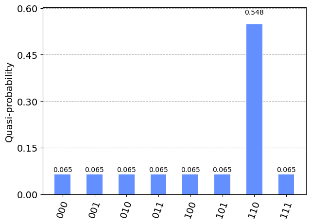

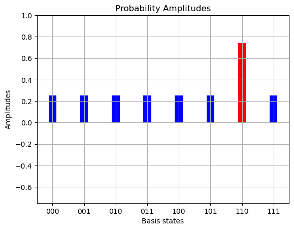

```python
# Define the Oracle circuit for the target state |110>
def grover_oracle_3qb(qc):
    qc.x(0)
    qc.h(2)
    qc.ccx(0, 1, 2)
    qc.h(2)
    qc.x(0)
    return qc

# Define the Diffuser circuit for 3-qubit system
def grover_diffuser_3qb(qc):
    qc.h(range(3))
    qc.x(range(3))
    qc.h(2)
    qc.ccx(0, 1, 2)
    qc.h(2)
    qc.x(range(3))
    qc.h(range(3))
    return qc

def plot_amplitudes_3qb(r, string):
    x_axis = np.arange(0, 8, 1)
    colors = ['blue'] * 7
    colors[6] = 'red'
    axis_labels = ['000', '001', '010', '011', '100', '101', '110', '111']

    plt.grid()
    plt.bar(x_axis, r, width=0.25, tick_label=axis_labels, color=colors)
    plt.ylim(-0.75, 1)

    plt.title(string)
    plt.xlabel('Basis states')
    plt.ylabel('Amplitudes')
    plt.show()

# Initialize the quantum circuit
t = init_n_qubit_circuit(3)
t.h([0, 1, 2])

# display the unitary matrix
oracle_circuit = QuantumCircuit(3)
grover_oracle_3qb(oracle_circuit)
oracle_operator = Operator(oracle_circuit)
latex_representation = oracle_operator.draw("latex")

print("Oracle Unitary Matrix:")
display(latex_representation)
print("Oracle Circuit:")
print(oracle_circuit.draw())

for i in range(5):
    # Apply Oracle
    grover_oracle_3qb(t)

    # Apply Diffuser
    grover_diffuser_3qb(t)

    print("Iteration", i+1)
    display(t.draw())

    # Obtain and print the state vector
    sv = Statevector(t)
    print("State vector after iteration", i+1, ":", sv)

    # Plot the probability distribution
    display(plot_distribution(sv.probabilities_dict()))

    # Plot the probability amplitudes
    plot_amplitudes_3qb(sv.data.real, "Probability Amplitudes")
```

Iteration 1: The probability of the target state |110⟩ is 0.781, significantly higher than the probabilities of other states. The probabilities of all other states are around 0.031, relatively low compared to the target state.

Iteration 2: The probability of |110⟩ increases to 0.945. The probabilities of all other states decrease, around 0.008.

Iteration 3: The probability of |110⟩ decreases to 0.330. The probabilities of all other states increase relatively, around 0.096, indicating the influence of interference effects.

Iteration 4: The probability of |110⟩ significantly decreases to 0.012, the algorithm is still seeking the optimal solution. The probabilities of all other states increase, around 0.141.

As the number of iterations increases, the probability of the target state changes and the probabilities of other states may oscillate. These changes reflect the interaction of superposition states in Grover's algorithm.

```
One iteration: Single-qubit gates: 21, Multi-qubit gates: 2
Two iterations: Single-qubit gates: 39, Multi-qubit gates: 4
Five iterations: Single-qubit gates: 93, Multi-qubit gates: 10
```